# Week1, Day2: Basic Data Visualisation

## Using ggplot Theme Assist

This user-friendly addin is a bit of a cheat for using ggplot. As a whole, it is best not to rely on it, otherwise you wont understand the underlying plot code that is generated. BUT! If you need a quick and easy way to edit your ggplot or you aren’t sure how to write the code to do so, it is very handy to install this addin.

```r
#install.packages("ggThemeAssist")

library(ggThemeAssist)
```

To use ggplot Theme Assist, you need to have the code for at least a basic graph. Highlight the code, go to ‘addins’ (just below the help button on the toolbar), and click **ggplot Theme Assist**.

Here is an example or the code you start out with, and the code you can finish with.

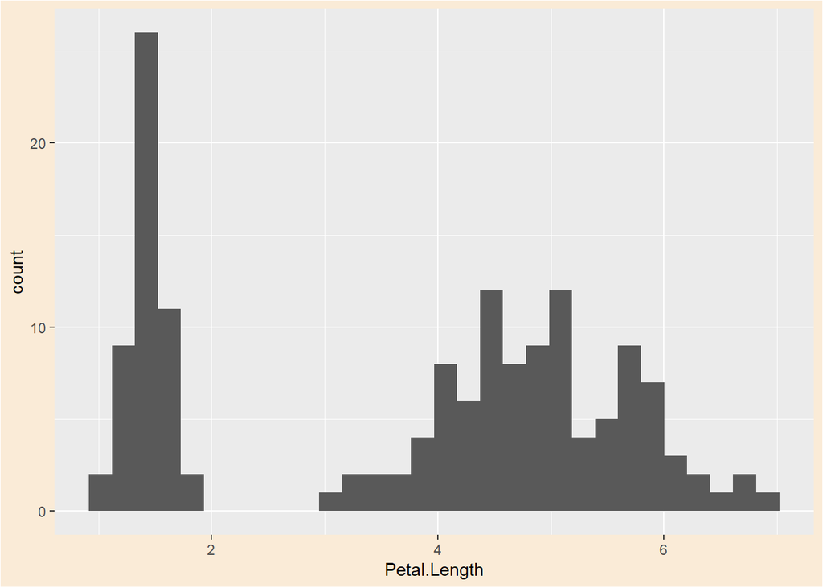

```r
# Create our simple dataframe again
iris <- as.data.frame(iris)


# Create our simple plot
gg <- ggplot(data = iris) +
  geom_histogram(aes(x = Petal.Length))

# either highlight plot code or assign the plot and use ggThemeAssistGadget()
#ggThemeAssistGadget(gg)

gg + theme(plot.background = element_rect(fill = "antiquewhite"))# it will automatically output the code, eg:
```

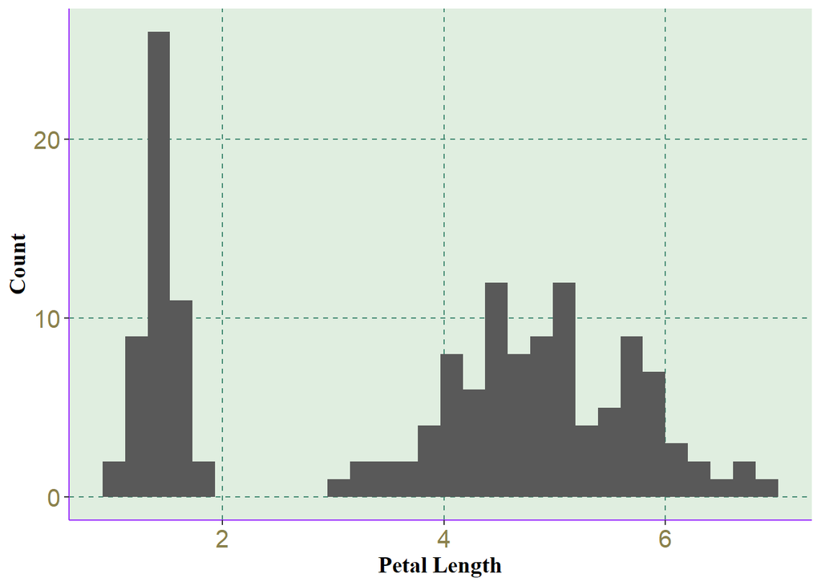

```r
ggplot(data = iris) +
  geom_histogram(aes(x = Petal.Length)) + theme(axis.line = element_line(colour = "purple1",
    linetype = "solid"), panel.grid.major = element_line(colour = "aquamarine4",
    linetype = "dashed"), panel.grid.minor = element_line(linetype = "blank"),
    axis.title = element_text(family = "serif",
        size = 14, face = "bold"), axis.text = element_text(size = 15,
        colour = "lightgoldenrod4"), plot.title = element_text(family = "serif",
        size = 20, face = "bold"), legend.text = element_text(colour = "bisque1"),
    panel.background = element_rect(fill = "honeydew2")) +labs(x = "Petal Length", y = "Count")
```

## Interactive plots

It is possible to create interactive plots using packages such as `plotly`. This is a whole universe in its own which we won’t go into in any detail, but you can just pass a ggplot object to plotly

```r
library(plotly)
p <- ggplot() +
  geom_line(data = ChickWeight[ChickWeight$Chick < 20,], aes(x = Time, y = weight, col = Chick))

ggplotly(p)
```

[interactive chart not shown]

```r
# Magic! Try hovering over the plot to see what happens
```

## Maps

We can use ggplot to create maps

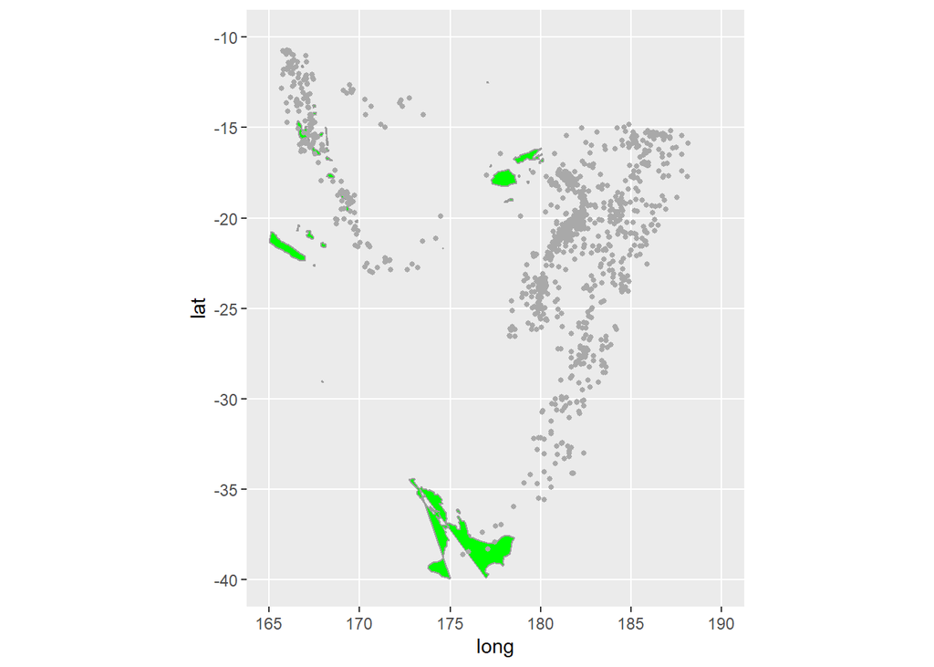

```r
# Let's use the quakes dataset again
data("quakes")
quakes_sf <- sf::st_as_sf(quakes, coords = c("long","lat"))

ggplot(quakes_sf) +
  geom_polygon(data = map_data("world"),
                 aes(x=long, y=lat, group = group),
                 color = '#9c9c9c', fill = 'green') +
  geom_sf(size = 1, color = 'dark grey') +
  xlim(165, 190)+
  ylim(-40, -10 )
```

An alternative package for maps is leaflet. This can be used to create interactive maps.

```r
library(leaflet)
leaflet(quakes_sf) %>%
  addTiles() %>%
  addCircles()
```

[interactive chart not shown]

## How to save plots

There are several options to save plots. In an R script, you can use the ‘save plot’ button above the plotting window. For ggplot, you can use `ggsave()` where you can define the location, format (jpeg, png, pdf) and dimensions of your outputs. You can also “print” to pdfs and pngs.

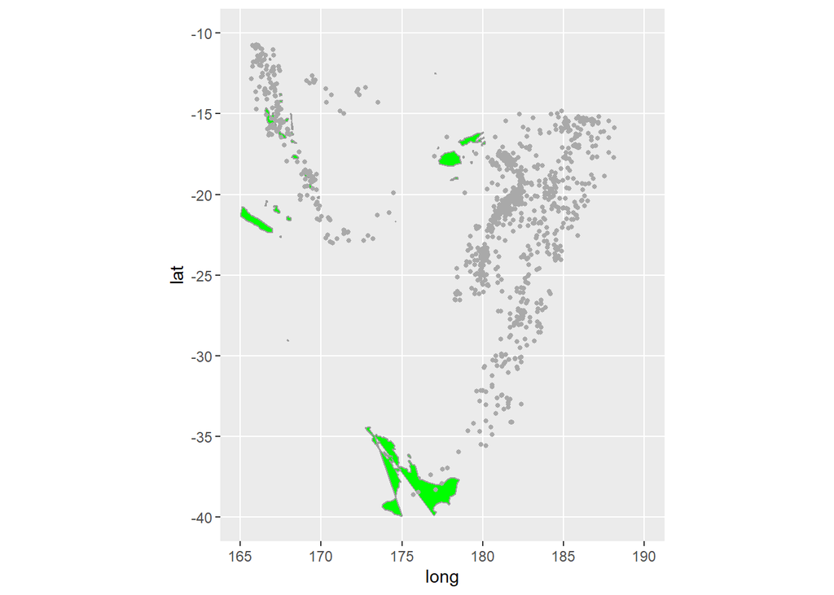

```r
ggplot(quakes_sf) +
  geom_polygon(data = map_data("world"),
                 aes(x=long, y=lat, group = group),
                 color = '#9c9c9c', fill = 'green') +
  geom_sf(size = 1, color = 'dark grey') +
  xlim(165, 190)+
  ylim(-40, -10 )
```

```r
ggsave("plot.png")
```

## Some further thoughts on plotting and online resources

There are many other things you can customise about your plots - both using base R functions and ggplot. There are also many other base R functions to produce specific statistical plots. Some examples of other things you can do when plotting:

- add labels/textboxes
- add trendlines
- plot outputs from statistical models, or plot error distributions
- customise the colour palette used in your plots – there are many palettes to choose from!
- arrange multiple plots, either using the `par` function, or using packages such as `cowplot`
- change the font size, style and angle of axis lables and tick marks
- plot spatial data using base R, ggplot or packages such as `leaflet`
- create animations and gifs which can be embedded into documents or exported as gifs

Like with many other things you can do in R, there are endless resources out there to help you! It is safe to assume that any plot customisation you want to do, someone else has already tried it and has asked the internet community for help (or went and wrote a book about it). Here are some links to get you started and to give you an idea of all the things you can look up online:

https://www.datanovia.com/en/lessons/introduction-to-ggplot2/

https://datacarpentry.org/R-ecology-lesson/04-visualization-ggplot2.html

https://stackoverflow.com/questions/57153428/r-plot-color-combinations-that-are-colorblind-accessible